# Physiological Genetics Explainer

Jeffrey A. Walker

23 January, 2024

# additive vs interaction effects of genotypes

## An introduction with an easy example

### Two genes are additive (no interaction!) if…

Two genes are additive if the genotype effect of gene A is the same for all genotypes of gene B. Huh?

The left panel in the image below illustrates this. The x-axis is the three genotypes of the CFTR locus. The y-axis is the thickness (viscosity) of mucus. The colors are the three genotypes of the AQP locus (one of the aquaporins).

1. Look at the three viscosities for the CFTR +/+ genotype. The viscosity depends on the genotype of the AQP locus – AQP +/+ has the most watery mucus (makes sense as 100% of the aquaporins are functional) and the h AQP -/- has the least watery mucus (again, makes sense). The difference in viscosity between the AQP genotypes at the CFTR +/+ genotype are the **effects of AQP** when CFTR is +/+.
2. Now look at the three viscosities for the CFTR -/+ genotype. The effects (the difference in viscosity between the three AQP genotypes) are the same at CFTR -/+ as at CFTR +/+. This sameness is reflected in the 3 parallel lines between the values at CFTR -/+ and CFTR +/+
3. Now look at the three viscosities for the CFTR -/- genotype. The effects (the difference in viscosity between the three AQP genotypes) are the same as at CFTR -/+. This sameness is reflected in the 3 parallel lines between the values at CFTR -/- and CFTR -/+. at CFTR -/+ and CFTR +/+. The effects (the difference in viscosity between the three AQP genotypes) *are also* the same as at CFTR +/+. This sameness is reflected in the 3 parallel lines between the values at CFTR -/- and CFTR +/+.

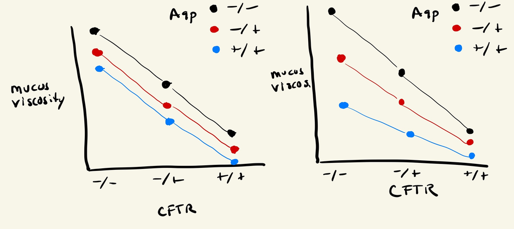

### Two genes interact (not additive) if…

Two genes **interact** (gene by gene interaction) if the genotype effect of gene A *depends on* the genotype of B. Huh?

The right panel in the image below illustrates this.

1. The three viscosities for the CFTR +/+ genotype are as above.
2. Now look at the three viscosities for the CFTR -/+ genotype. The effects (the difference in viscosity between the three AQP genotypes) are *a little bigger* than at CFTR +/+. The effects of AQP at CFTR -/+ *differ* from the effects at CFTR +/+. This difference is reflected in the 3 non-parallel lines between the values at CFTR -/+ and CFTR +/+
3. The exact logic in item two applies to CFTR -/-, except the differences (the effect of AQP) are even bigger than at CFTR -/+.

Key: I think in class that I said something like this: “a gene by gene interaction occurs when the genotype to phenotype mapping at one locus is depends on the genotype at a second locus.” This is only correct if we think of this in terms of **effect** and not absolute phenotypic value. For example, in the left panel, the genotype to phenotype mapping at CFTR +/+ *depends on* the genotype of AQP. **But this doesn not mean there is a CFTR by AQP interaction**. For an interaction, we need to compare the effect of gene B at each of the genotypes of gene A. If the genotype effect of gene A is not the same for at least one genotype of gene B, there is an interaction. This is shown in the right panel, where the effects of AQP *depend on* the genotype of CFTR. This is easily seen in the plot by the non-parallel lines.

## A less easy example

1. Without going into the detail, I’ll just say the the effects of CFTR and AQP are additive in the left panel and non-additive (there is a gene by gene interaction) in the right panel. **Do not be confused by the kinked color lines(**. In the left panel, the three colored lines linking viscosity for CFTR -/- and CFTR -/+ are parallel **and** the three colored lines linking viscosity for CFTR -/+ and CFTR +/+ are parallel. So the genes are additive and there is no interaction.
2. But, in the right panel, while the three colored lines linking viscosity for CFTR -/+ and CFTR +/+ are parallel, the three colored lines linking CFTR -/- and CFTR -/+ are not parallel – there is a gene by gene (CFTR by AQP) interaction. It doesn’t matter that some lines are parallel.

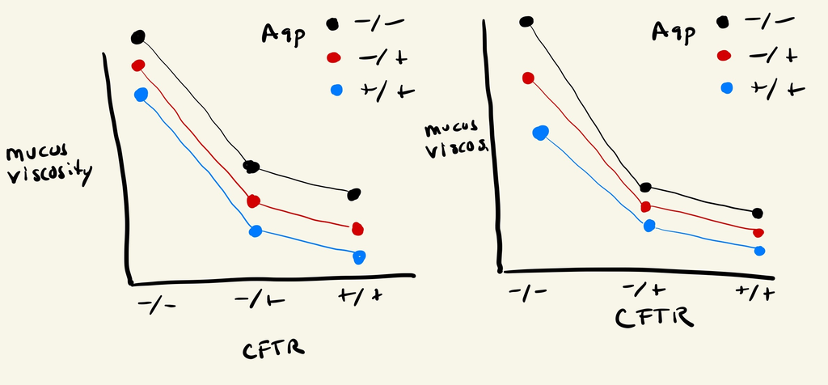